# cleaning data

2022-09-02

# Tidyverse

Tidyverse is a collection of R packages that are extremely useful to data manipulation and analysis.

```r
library(tidyverse)
```

# Data frames and data types

We are going to look at a dataset called msleep that is included in the tidyverse package.

```r
View(msleep)
```

Some useful functions to get an overview of what your data looks like:

```r
head(msleep)
```

```
## # A tibble: 6 x 11
##   name    genus vore  order conservation sleep_total sleep_rem sleep_cycle awake
##   <chr>   <chr> <chr> <chr> <chr>              <dbl>     <dbl>       <dbl> <dbl>
## 1 Cheetah Acin~ carni Carn~ lc                  12.1      NA        NA      11.9
## 2 Owl mo~ Aotus omni  Prim~ <NA>                17         1.8      NA       7
## 3 Mounta~ Aplo~ herbi Rode~ nt                  14.4       2.4      NA       9.6
## 4 Greate~ Blar~ omni  Sori~ lc                  14.9       2.3       0.133   9.1
## 5 Cow     Bos   herbi Arti~ domesticated         4         0.7       0.667  20
## 6 Three-~ Brad~ herbi Pilo~ <NA>                14.4       2.2       0.767   9.6
## # ... with 2 more variables: brainwt <dbl>, bodywt <dbl>
```

```r
tail(msleep)
```

```
## # A tibble: 6 x 11
##   name    genus vore  order conservation sleep_total sleep_rem sleep_cycle awake
##   <chr>   <chr> <chr> <chr> <chr>              <dbl>     <dbl>       <dbl> <dbl>
## 1 Tenrec  Tenr~ omni  Afro~ <NA>                15.6       2.3      NA       8.4
## 2 Tree s~ Tupa~ omni  Scan~ <NA>                 8.9       2.6       0.233  15.1
## 3 Bottle~ Turs~ carni Ceta~ <NA>                 5.2      NA        NA      18.8
## 4 Genet   Gene~ carni Carn~ <NA>                 6.3       1.3      NA      17.7
## 5 Arctic~ Vulp~ carni Carn~ <NA>                12.5      NA        NA      11.5
## 6 Red fox Vulp~ carni Carn~ <NA>                 9.8       2.4       0.35   14.2
## # ... with 2 more variables: brainwt <dbl>, bodywt <dbl>
```

```r
dim(msleep)
```

```
## [1] 83 11
```

```r
str(msleep)
```

```
## tibble [83 x 11] (S3: tbl_df/tbl/data.frame)
##  $ name        : chr [1:83] "Cheetah" "Owl monkey" "Mountain beaver" "Greater short-tailed shrew" ...
##  $ genus       : chr [1:83] "Acinonyx" "Aotus" "Aplodontia" "Blarina" ...
##  $ vore        : chr [1:83] "carni" "omni" "herbi" "omni" ...
##  $ order       : chr [1:83] "Carnivora" "Primates" "Rodentia" "Soricomorpha" ...
##  $ conservation: chr [1:83] "lc" NA "nt" "lc" ...
##  $ sleep_total : num [1:83] 12.1 17 14.4 14.9 4 14.4 8.7 7 10.1 3 ...
##  $ sleep_rem   : num [1:83] NA 1.8 2.4 2.3 0.7 2.2 1.4 NA 2.9 NA ...
##  $ sleep_cycle : num [1:83] NA NA NA 0.133 0.667 ...
##  $ awake       : num [1:83] 11.9 7 9.6 9.1 20 9.6 15.3 17 13.9 21 ...
##  $ brainwt     : num [1:83] NA 0.0155 NA 0.00029 0.423 NA NA NA 0.07 0.0982 ...
##  $ bodywt      : num [1:83] 50 0.48 1.35 0.019 600 ...
```

```r
names(msleep)
```

```
##  [1] "name"         "genus"        "vore"         "order"        "conservation"
##  [6] "sleep_total"  "sleep_rem"    "sleep_cycle"  "awake"        "brainwt"
## [11] "bodywt"
```

Note in the output of str() that data type (here either chr or num). R has six data types:

numeric: numbers like 1 and 16.823 (sometimes also called double). logical: true/false values (boolean): either TRUE or FALSE. character: text, e.g. “a”, “Hello! I’m Ada.” and “name@domain.com”. integer: integer numbers, denoted in R by the letter L: 1L, 55L. complex: complex numbers, like 2+3i. raw: used to hold raw bytes.

You will probably only need to think about the top three.

## Numerical data

summary() gives some descriptive information about the numerical variables

```r
summary(msleep)
```

```
##      name              genus               vore              order
##  Length:83          Length:83          Length:83          Length:83
##  Class :character   Class :character   Class :character   Class :character
##  Mode  :character   Mode  :character   Mode  :character   Mode  :character
##
##
##
##
##  conservation        sleep_total      sleep_rem      sleep_cycle
##  Length:83          Min.   : 1.90   Min.   :0.100   Min.   :0.1167
##  Class :character   1st Qu.: 7.85   1st Qu.:0.900   1st Qu.:0.1833
##  Mode  :character   Median :10.10   Median :1.500   Median :0.3333
##                     Mean   :10.43   Mean   :1.875   Mean   :0.4396
##                     3rd Qu.:13.75   3rd Qu.:2.400   3rd Qu.:0.5792
##                     Max.   :19.90   Max.   :6.600   Max.   :1.5000
##                                     NA's   :22      NA's   :51
##      awake          brainwt            bodywt
##  Min.   : 4.10   Min.   :0.00014   Min.   :   0.005
##  1st Qu.:10.25   1st Qu.:0.00290   1st Qu.:   0.174
##  Median :13.90   Median :0.01240   Median :   1.670
##  Mean   :13.57   Mean   :0.28158   Mean   : 166.136
##  3rd Qu.:16.15   3rd Qu.:0.12550   3rd Qu.:  41.750
##  Max.   :22.10   Max.   :5.71200   Max.   :6654.000
##                  NA's   :27
```

Can use the $ sign to look at individual columns

```r
msleep$sleep_total
```

```
##  [1] 12.1 17.0 14.4 14.9  4.0 14.4  8.7  7.0 10.1  3.0  5.3  9.4 10.0 12.5 10.3
## [16]  8.3  9.1 17.4  5.3 18.0  3.9 19.7  2.9  3.1 10.1 10.9 14.9 12.5  9.8  1.9
## [31]  2.7  6.2  6.3  8.0  9.5  3.3 19.4 10.1 14.2 14.3 12.8 12.5 19.9 14.6 11.0
## [46]  7.7 14.5  8.4  3.8  9.7 15.8 10.4 13.5  9.4 10.3 11.0 11.5 13.7  3.5  5.6
## [61] 11.1 18.1  5.4 13.0  8.7  9.6  8.4 11.3 10.6 16.6 13.8 15.9 12.8  9.1  8.6
## [76] 15.8  4.4 15.6  8.9  5.2  6.3 12.5  9.8
```

Useful functions:

```r
mean(msleep$sleep_total)      # Mean
```

```
## [1] 10.43373
```

```r
median(msleep$sleep_total)    # Median
```

```
## [1] 10.1
```

```r
max(msleep$sleep_total)       # Max
```

```
## [1] 19.9
```

```r
min(msleep$sleep_total)       # Min
```

```
## [1] 1.9
```

```r
sd(msleep$sleep_total)        # Standard deviation
```

```
## [1] 4.450357
```

```r
var(msleep$sleep_total)       # Variance
```

```
## [1] 19.80568
```

```r
quantile(msleep$sleep_total)  # Various quantiles
```

```
##    0%   25%   50%   75%  100%
##  1.90  7.85 10.10 13.75 19.90
```

To see how many/the proportion of rows that fulfil a certain criteria, e.g. the number of proportion of animals with >8 hours of sleep:

```r
sum(msleep$sleep_total > 8)   # Frequency (count)
```

```
## [1] 61
```

```r
mean(msleep$sleep_total > 8)  # Relative frequency (proportion)
```

```
## [1] 0.7349398
```

If you have missing data (which show as NA), some functions will show an NA, e.g.

```r
mean(msleep$sleep_rem)
```

```
## [1] NA
```

Can ignore NAs with the na.rm = TRUE argument

```r
mean(msleep$sleep_rem, na.rm = TRUE)
```

```
## [1] 1.87541
```

## Categorical data

With factor variables, we can look at frequencies and proportions:

```r
table(msleep$vore)
```

```
##
##   carni   herbi insecti    omni
##      19      32       5      20
```

```r
proportions(table(msleep$vore))
```

```
##
##      carni      herbi    insecti       omni
## 0.25000000 0.42105263 0.06578947 0.26315789
```

for single variables or for combinations of two categorical variables:

```r
# Counts:
table(msleep$vore, msleep$conservation)
```

```
##
##           cd domesticated en lc nt vu
##   carni    1            2  1  5  1  4
##   herbi    1            7  2 10  3  3
##   insecti  0            0  1  2  0  0
##   omni     0            1  0  8  0  0
```

```r
# Proportions, per row:
proportions(table(msleep$vore, msleep$conservation),
            margin = 1)
```

```
##
##                   cd domesticated         en         lc         nt         vu
##   carni   0.07142857   0.14285714 0.07142857 0.35714286 0.07142857 0.28571429
##   herbi   0.03846154   0.26923077 0.07692308 0.38461538 0.11538462 0.11538462
##   insecti 0.00000000   0.00000000 0.33333333 0.66666667 0.00000000 0.00000000
##   omni    0.00000000   0.11111111 0.00000000 0.88888889 0.00000000 0.00000000
```

```r
# Proportions, per column:
proportions(table(msleep$vore, msleep$conservation),
            margin = 2)
```

```
##
##                  cd domesticated        en        lc        nt        vu
##   carni   0.5000000    0.2000000 0.2500000 0.2000000 0.2500000 0.5714286
##   herbi   0.5000000    0.7000000 0.5000000 0.4000000 0.7500000 0.4285714
##   insecti 0.0000000    0.0000000 0.2500000 0.0800000 0.0000000 0.0000000
##   omni    0.0000000    0.1000000 0.0000000 0.3200000 0.0000000 0.0000000
```

## Changing types

Factors: Say you have a study with two groups, group 1 and group 2. The labels 1 and 2 are just labels, they could just as easily be group A and group B or group “experimental” and “control”.

We need to tell R that these are categorical and not numerical. This is important because say for example you have 3 groups, 1,2 and 3, there’s no way in which group 1 + group 2 = group 3. It also doesn’t make sense to say that someone in group 3 is twice as far from someone in group 1 as someone in group 2. We can tell R this by making the variable a factor, with the as.factor() function.

```r
group <- c(1,1,2,1,2,1,2,2,1)

class(group)
```

```
## [1] "numeric"
```

```r
group <- as.factor(group)

class(group)
```

```
## [1] "factor"
```

# Using %>% pipes

Within the tidyverse is a set of tools called *pipes*. These are operators that improve your code’s readability and structure the code in such a way that you read the functions in the order that they are applied instead of inside out. E.g

new_variable <- function_2(function_1(data))

becomes

new_variable <- data %>% function_1 %>% function_2

For example:

```r
height <- c(160, 163, 170, 172,175, 178, 180, 182, 185, 190, 191, 190, 166)

mean(log(height))
```

```
## [1] 5.174955
```

```r
height %>%
  log %>%
  mean
```

```
## [1] 5.174955
```

# Modifying a variable

Say we want to change the sleep_total column to be in minutes instead of hours. For this we can use the *mutate* function

```r
msleep$sleep_total
```

```
##  [1] 12.1 17.0 14.4 14.9  4.0 14.4  8.7  7.0 10.1  3.0  5.3  9.4 10.0 12.5 10.3
## [16]  8.3  9.1 17.4  5.3 18.0  3.9 19.7  2.9  3.1 10.1 10.9 14.9 12.5  9.8  1.9
## [31]  2.7  6.2  6.3  8.0  9.5  3.3 19.4 10.1 14.2 14.3 12.8 12.5 19.9 14.6 11.0
## [46]  7.7 14.5  8.4  3.8  9.7 15.8 10.4 13.5  9.4 10.3 11.0 11.5 13.7  3.5  5.6
## [61] 11.1 18.1  5.4 13.0  8.7  9.6  8.4 11.3 10.6 16.6 13.8 15.9 12.8  9.1  8.6
## [76] 15.8  4.4 15.6  8.9  5.2  6.3 12.5  9.8
```

```r
msleep <- msleep %>%
  mutate(sleep_total = sleep_total*60)
```

Say we have a reversed item on a scale

```r
example_data <- example_data %>%
  mutate(item_2R = 7 - item_2R,
         item_4R = 7 - item_4R)
```

# Create a new variables

The mutate function also allows the creation of a new variable.

Say we want to create a column showing the ratio of brain weight to body weight:

```r
msleep <- msleep %>%
  mutate(brain_body_ratio = 100*brainwt/bodywt)

msleep
```

```
## # A tibble: 83 x 12
##    name   genus vore  order conservation sleep_total sleep_rem sleep_cycle awake
##    <chr>  <chr> <chr> <chr> <chr>              <dbl>     <dbl>       <dbl> <dbl>
##  1 Cheet~ Acin~ carni Carn~ lc                   726      NA        NA      11.9
##  2 Owl m~ Aotus omni  Prim~ <NA>                1020       1.8      NA       7
##  3 Mount~ Aplo~ herbi Rode~ nt                   864       2.4      NA       9.6
##  4 Great~ Blar~ omni  Sori~ lc                   894       2.3       0.133   9.1
##  5 Cow    Bos   herbi Arti~ domesticated         240       0.7       0.667  20
##  6 Three~ Brad~ herbi Pilo~ <NA>                 864       2.2       0.767   9.6
##  7 North~ Call~ carni Carn~ vu                   522       1.4       0.383  15.3
##  8 Vespe~ Calo~ <NA>  Rode~ <NA>                 420      NA        NA      17
##  9 Dog    Canis carni Carn~ domesticated         606       2.9       0.333  13.9
## 10 Roe d~ Capr~ herbi Arti~ lc                   180      NA        NA      21
## # ... with 73 more rows, and 3 more variables: brainwt <dbl>, bodywt <dbl>,
## #   brain_body_ratio <dbl>
```

Say we want to create a column that has the mean value of the items in a scale

```r
example_data %>%
  mutate(scale_mean = rowMeans(select(., item_1:item_4R)))
```

```
##    subject item_1 item_2R item_3 item_4R                 item_5 scale_mean
## 1        1      6       6      2       6  Somewhat dissatisfied       5.00
## 2        2      4       4      2       1  Somewhat dissatisfied       2.75
## 3        3      5       2      5       6  Somewhat dissatisfied       4.50
## 4        4      3       5      4       3      Very dissatisfied       3.75
## 5        5      3       2      2       5 Extremely dissatisfied       3.00
## 6        6      6       2      3       4      Very dissatisfied       3.75
## 7        7      4       4      6       6         Very satisfied       5.00
## 8        8      5       3      2       2 Extremely dissatisfied       3.00
## 9        9      5       3      3       5  Somewhat dissatisfied       4.00
## 10      10      2       1      3       5  Somewhat dissatisfied       2.75
```

# Rename variable

```r
msleep <- msleep %>%
  rename(sleep_total_mins = sleep_total)

msleep
```

```
## # A tibble: 83 x 12
##    name    genus vore  order conservation sleep_total_mins sleep_rem sleep_cycle
##    <chr>   <chr> <chr> <chr> <chr>                   <dbl>     <dbl>       <dbl>
##  1 Cheetah Acin~ carni Carn~ lc                        726      NA        NA
##  2 Owl mo~ Aotus omni  Prim~ <NA>                     1020       1.8      NA
##  3 Mounta~ Aplo~ herbi Rode~ nt                        864       2.4      NA
##  4 Greate~ Blar~ omni  Sori~ lc                        894       2.3       0.133
##  5 Cow     Bos   herbi Arti~ domesticated              240       0.7       0.667
##  6 Three-~ Brad~ herbi Pilo~ <NA>                      864       2.2       0.767
##  7 Northe~ Call~ carni Carn~ vu                        522       1.4       0.383
##  8 Vesper~ Calo~ <NA>  Rode~ <NA>                      420      NA        NA
##  9 Dog     Canis carni Carn~ domesticated              606       2.9       0.333
## 10 Roe de~ Capr~ herbi Arti~ lc                        180      NA        NA
## # ... with 73 more rows, and 4 more variables: awake <dbl>, brainwt <dbl>,
## #   bodywt <dbl>, brain_body_ratio <dbl>
```

# Select or remove particular variables

```r
# can select each column by name
msleep %>%
  select(name, genus, vore, order, conservation)
```

```
## # A tibble: 83 x 5
##    name                       genus       vore  order        conservation
##    <chr>                      <chr>       <chr> <chr>        <chr>
##  1 Cheetah                    Acinonyx    carni Carnivora    lc
##  2 Owl monkey                 Aotus       omni  Primates     <NA>
##  3 Mountain beaver            Aplodontia  herbi Rodentia     nt
##  4 Greater short-tailed shrew Blarina     omni  Soricomorpha lc
##  5 Cow                        Bos         herbi Artiodactyla domesticated
##  6 Three-toed sloth           Bradypus    herbi Pilosa       <NA>
##  7 Northern fur seal          Callorhinus carni Carnivora    vu
##  8 Vesper mouse               Calomys     <NA>  Rodentia     <NA>
##  9 Dog                        Canis       carni Carnivora    domesticated
## 10 Roe deer                   Capreolus   herbi Artiodactyla lc
## # ... with 73 more rows
```

```r
# or by range
msleep %>%
  select(name:conservation)
```

```
## # A tibble: 83 x 5
##    name                       genus       vore  order        conservation
##    <chr>                      <chr>       <chr> <chr>        <chr>
##  1 Cheetah                    Acinonyx    carni Carnivora    lc
##  2 Owl monkey                 Aotus       omni  Primates     <NA>
##  3 Mountain beaver            Aplodontia  herbi Rodentia     nt
##  4 Greater short-tailed shrew Blarina     omni  Soricomorpha lc
##  5 Cow                        Bos         herbi Artiodactyla domesticated
##  6 Three-toed sloth           Bradypus    herbi Pilosa       <NA>
##  7 Northern fur seal          Callorhinus carni Carnivora    vu
##  8 Vesper mouse               Calomys     <NA>  Rodentia     <NA>
##  9 Dog                        Canis       carni Carnivora    domesticated
## 10 Roe deer                   Capreolus   herbi Artiodactyla lc
## # ... with 73 more rows
```

```r
# remove columns using the - sign
msleep %>%
  select(-genus)
```

```
## # A tibble: 83 x 11
##    name    vore  order conservation sleep_total_mins sleep_rem sleep_cycle awake
##    <chr>   <chr> <chr> <chr>                   <dbl>     <dbl>       <dbl> <dbl>
##  1 Cheetah carni Carn~ lc                        726      NA        NA      11.9
##  2 Owl mo~ omni  Prim~ <NA>                     1020       1.8      NA       7
##  3 Mounta~ herbi Rode~ nt                        864       2.4      NA       9.6
##  4 Greate~ omni  Sori~ lc                        894       2.3       0.133   9.1
##  5 Cow     herbi Arti~ domesticated              240       0.7       0.667  20
##  6 Three-~ herbi Pilo~ <NA>                      864       2.2       0.767   9.6
##  7 Northe~ carni Carn~ vu                        522       1.4       0.383  15.3
##  8 Vesper~ <NA>  Rode~ <NA>                      420      NA        NA      17
##  9 Dog     carni Carn~ domesticated              606       2.9       0.333  13.9
## 10 Roe de~ herbi Arti~ lc                        180      NA        NA      21
## # ... with 73 more rows, and 3 more variables: brainwt <dbl>, bodywt <dbl>,
## #   brain_body_ratio <dbl>
```

# Recoding variables

Say we have gender coded as 0 and 1, we might want to recode this explicitly as male and female for clarity. Or say we have items in a scale that have responses such as “Not at all”, “Very much” that we want to recode as numeric:

```r
example_data %>%
  mutate(item_5 = recode(item_5,
                         "Extremely dissatisfied" = 1,
                         "Very dissatisfied" = 2,
                         "Somewhat dissatisfied" = 3,
                         "Somewhat satisfied" = 4,
                         "Very satisfied" = 5,
                         "Extremely satisfied" = 6))
```

```
##    subject item_1 item_2R item_3 item_4R item_5
## 1        1      6       6      2       6      3
## 2        2      4       4      2       1      3
## 3        3      5       2      5       6      3
## 4        4      3       5      4       3      2
## 5        5      3       2      2       5      1
## 6        6      6       2      3       4      2
## 7        7      4       4      6       6      5
## 8        8      5       3      2       2      1
## 9        9      5       3      3       5      3
## 10      10      2       1      3       5      3
```

```r
example_data <- example_data %>%
  mutate(item_5 = recode(item_5,
                         `1` = "Extremely dissatisfied",
                         `2` = "Very dissatisfied",
                         `3` = "Somewhat dissatisfied",
                         `4` = "Somewhat satisfied",
                         `5` = "Very satisfied",
                         `6` = "Extremely satisfied"))
```

# Grouped summaries

Commonly we want to compute a function for each value of a variable. Let’s look at the airquality dataset:

```r
library(data.table)
?airquality
```

```
## starting httpd help server ...
```

```
##  done
```

```r
aq <- data.table(airquality)
```

What if we want to compare how a particular variable varies over the months - it would make sense to look at key summary values e.g. the mean and standard deviation for each month separately. This is how to do this using tidyverse:

```r
aq %>%
  group_by(Month) %>%
  summarise(meanTemp = mean(Temp))
```

```
## # A tibble: 5 x 2
##   Month meanTemp
##   <int>    <dbl>
## 1     5     65.5
## 2     6     79.1
## 3     7     83.9
## 4     8     84.0
## 5     9     76.9
```

If we have NA values there, we can use na.rm = TRUE argument:

```r
aq %>%
  group_by(Month) %>%
  summarise(meanOzone = mean(Ozone))
```

```
## # A tibble: 5 x 2
##   Month meanOzone
##   <int>     <dbl>
## 1     5        NA
## 2     6        NA
## 3     7        NA
## 4     8        NA
## 5     9        NA
```

```r
aq %>%
  group_by(Month) %>%
  summarise(meanOzone = mean(Ozone,
                             na.rm = TRUE))
```

```
## # A tibble: 5 x 2
##   Month meanOzone
##   <int>     <dbl>
## 1     5      23.6
## 2     6      29.4
## 3     7      59.1
## 4     8      60.0
## 5     9      31.4
```

We can compute summary statistics that use multiple variables, or multiple summary statistics at once:

```r
aq %>%
  group_by(Month) %>%
  summarise(meanTemp = mean(Temp),
            correlation = cor(Temp, Wind))
```

```
## # A tibble: 5 x 3
##   Month meanTemp correlation
##   <int>    <dbl>       <dbl>
## 1     5     65.5      -0.373
## 2     6     79.1      -0.121
## 3     7     83.9      -0.305
## 4     8     84.0      -0.508
## 5     9     76.9      -0.570
```

We can also summarise across many variables that share a property, for example say we want to create means for all numeric variables:

```r
aq %>%
  group_by(Month) %>%
  summarise(across(
    where(is.numeric),
    mean, na.rm = TRUE
  ))
```

```
## # A tibble: 5 x 6
##   Month Ozone Solar.R  Wind  Temp   Day
##   <int> <dbl>   <dbl> <dbl> <dbl> <dbl>
## 1     5  23.6    181. 11.6   65.5  16
## 2     6  29.4    190. 10.3   79.1  15.5
## 3     7  59.1    216.  8.94  83.9  16
## 4     8  60.0    172.  8.79  84.0  16
## 5     9  31.4    167. 10.2   76.9  15.5
```

We can also simply count how many occurences there are of a particular variable using n():

```r
aq %>%
  group_by(Month) %>%
  summarise(days = n())
```

```
## # A tibble: 5 x 2
##   Month  days
##   <int> <int>
## 1     5    31
## 2     6    30
## 3     7    31
## 4     8    31
## 5     9    30
```

and the number of *distinct* occurences of a variable using n_distinct():

```r
aq %>% summarise(months =
  n_distinct(Month))
```

```
##   months
## 1      5
```

# Filling in missing values

Sometimes we might want to fill in some missing values with the previous non-missing value. First let’s put in some missing data in our dataset:

```r
aq$Month[c(2:3, 36:39, 70)] <- NA

# Some values of Month are now missing:
head(aq)
```

```
##    Ozone Solar.R Wind Temp Month Day
## 1:    41     190  7.4   67     5   1
## 2:    36     118  8.0   72    NA   2
## 3:    12     149 12.6   74    NA   3
## 4:    18     313 11.5   62     5   4
## 5:    NA      NA 14.3   56     5   5
## 6:    28      NA 14.9   66     5   6
```

Let’s fill in the gaps:

```r
aq %>%
  fill(Month) ->
  aq

head(aq)
```

```
##    Ozone Solar.R Wind Temp Month Day
## 1:    41     190  7.4   67     5   1
## 2:    36     118  8.0   72     5   2
## 3:    12     149 12.6   74     5   3
## 4:    18     313 11.5   62     5   4
## 5:    NA      NA 14.3   56     5   5
## 6:    28      NA 14.9   66     5   6
```

To fill them in with the *next* non-missing value, use .direction = “up”:

```r
aq %>% fill(Month,
        .direction = "up") -> aq
```

# Combining multiple steps:

With the %>% function we can achieve multiple steps in one piece of code in a readable and ordered way.

```r
aq %>% fill(Month) %>%
       group_by(Month) %>%
       summarise(days = n())
```

```
## # A tibble: 5 x 2
##   Month  days
##   <int> <int>
## 1     5    31
## 2     6    30
## 3     7    31
## 4     8    31
## 5     9    30
```

# Filtering

Using slice:

```r
# By index:
aq %>%
  slice(4)
```

```
##    Ozone Solar.R Wind Temp Month Day
## 1:    18     313 11.5   62     5   4
```

```r
# By range:
aq %>%
  slice(1:4)
```

```
##    Ozone Solar.R Wind Temp Month Day
## 1:    41     190  7.4   67     5   1
## 2:    36     118  8.0   72     5   2
## 3:    12     149 12.6   74     5   3
## 4:    18     313 11.5   62     5   4
```

```r
# By explicitly choosing rows:
aq %>%
  slice(c(2,6,7))
```

```
##    Ozone Solar.R Wind Temp Month Day
## 1:    36     118  8.0   72     5   2
## 2:    28      NA 14.9   66     5   6
## 3:    23     299  8.6   65     5   7
```

```r
# To remove rows:
aq %>%
  slice(-4)
```

```
##      Ozone Solar.R Wind Temp Month Day
##   1:    41     190  7.4   67     5   1
##   2:    36     118  8.0   72     5   2
##   3:    12     149 12.6   74     5   3
##   4:    NA      NA 14.3   56     5   5
##   5:    28      NA 14.9   66     5   6
##  ---
## 148:    30     193  6.9   70     9  26
## 149:    NA     145 13.2   77     9  27
## 150:    14     191 14.3   75     9  28
## 151:    18     131  8.0   76     9  29
## 152:    20     223 11.5   68     9  30
```

Using conditions:

```r
aq %>%
  filter(Temp > 90)
```

```
##     Ozone Solar.R Wind Temp Month Day
##  1:    NA     259 10.9   93     6  11
##  2:    NA     250  9.2   92     6  12
##  3:    97     267  6.3   92     7   8
##  4:    97     272  5.7   92     7   9
##  5:    NA     291 14.9   91     7  14
##  6:    NA     222  8.6   92     8  10
##  7:    76     203  9.7   97     8  28
##  8:   118     225  2.3   94     8  29
##  9:    84     237  6.3   96     8  30
## 10:    85     188  6.3   94     8  31
## 11:    96     167  6.9   91     9   1
## 12:    78     197  5.1   92     9   2
## 13:    73     183  2.8   93     9   3
## 14:    91     189  4.6   93     9   4
```

```r
aq %>%
  filter(Month == 6)
```

```
##     Ozone Solar.R Wind Temp Month Day
##  1:    NA     286  8.6   78     6   1
##  2:    NA     287  9.7   74     6   2
##  3:    NA     242 16.1   67     6   3
##  4:    NA     186  9.2   84     6   4
##  5:    NA     220  8.6   85     6   5
##  6:    NA     264 14.3   79     6   6
##  7:    29     127  9.7   82     6   7
##  8:    NA     273  6.9   87     6   8
##  9:    71     291 13.8   90     6   9
## 10:    39     323 11.5   87     6  10
## 11:    NA     259 10.9   93     6  11
## 12:    NA     250  9.2   92     6  12
## 13:    23     148  8.0   82     6  13
## 14:    NA     332 13.8   80     6  14
```

[output cut: 17 more lines]

Note: Look out for this double equals sign here, it means something different to the single equals sign. = is an assignment operator (similar to <-), == is a logical comparison, i.e. we use this when we want to *test equality*.

```r
help("=")
help("==")
```

# Merging data from multiple sources

It might be the case that for one project we have data from multiple sources that we want to combine into one data frame. For example,

```r
rev_data <- read.csv("data/sales-rev.csv", sep = ";")
weather_data <- read.csv("data/sales-weather.csv", sep = ";")

str(rev_data)
```

```
## 'data.frame':    90 obs. of  2 variables:
##  $ DATE   : chr  "2020-01-01" "2020-01-02" "2020-01-03" "2020-01-04" ...
##  $ REVENUE: int  7637 9276 11170 11863 10880 6702 8652 8346 6543 8115 ...
```

```r
str(weather_data)
```

```
## 'data.frame':    87 obs. of  5 variables:
##  $ DATE         : chr  "2020-01-01" "2020-01-02" "2020-01-03" "2020-01-04" ...
##  $ SUN_HOURS    : num  0 0.372 0.264 3.549 2.513 ...
##  $ PRECIPITATION: num  0 0 0 0 2.4 0.2 0 0 0.6 0 ...
##  $ SNOW_DEPTH   : num  0 0 0 0 0 0 0 0 0 0 ...
##  $ TEMPERATURE  : num  0 5.8 5.4 2.4 0.1 4.8 5.5 6.5 3.9 1 ...
```

If you are lucky and the rows or columns match each other_exactly_ you can use bind to connect the two dataframes.

Let’s first extract three subsets of these dataframes: the revenue for January, the revenue for February and the weather for January:

```r
rev_data %>% filter(between(DATE,
            as.Date("2020-01-01"),
            as.Date("2020-01-31"))
                    ) -> rev_jan

rev_data %>% filter(between(DATE,
            as.Date("2020-02-01"),
            as.Date("2020-02-29"))
                    ) -> rev_feb

weather_data %>% filter(between(
            DATE,
            as.Date("2020-01-01"),
            as.Date("2020-01-31"))
                 ) -> weather_jan
```

We can see the rows of rev_jan and weather_jan correspond exactly, which means we can bind the columns together. Similarly, rev_jan and rev_feb have identical columns, so we could bind their rows together. Let’s see:

```r
bind_rows(rev_jan, rev_feb)
```

```
##          DATE REVENUE
## 1  2020-01-01    7637
## 2  2020-01-02    9276
## 3  2020-01-03   11170
## 4  2020-01-04   11863
## 5  2020-01-05   10880
## 6  2020-01-06    6702
## 7  2020-01-07    8652
## 8  2020-01-08    8346
## 9  2020-01-09    6543
## 10 2020-01-10    8115
## 11 2020-01-11    7728
## 12 2020-01-12   10649
## 13 2020-01-13    6787
## 14 2020-01-14    4555
```

[output cut: 46 more lines]

```r
bind_cols(rev_jan, weather_jan)
```

```
##      DATE...1 REVENUE   DATE...3  SUN_HOURS PRECIPITATION SNOW_DEPTH
## 1  2020-01-01    7637 2020-01-01 0.00000000           0.0          0
## 2  2020-01-02    9276 2020-01-02 0.37250000           0.0          0
## 3  2020-01-03   11170 2020-01-03 0.26361111           0.0          0
## 4  2020-01-04   11863 2020-01-04 3.54861111           0.0          0
## 5  2020-01-05   10880 2020-01-05 2.51250000           2.4          0
## 6  2020-01-06    6702 2020-01-06 0.09333333           0.2          0
## 7  2020-01-07    8652 2020-01-07 0.00000000           0.0          0
## 8  2020-01-08    8346 2020-01-08 0.16166667           0.0          0
## 9  2020-01-09    6543 2020-01-09 0.31944444           0.6          0
## 10 2020-01-10    8115 2020-01-10 1.58694444           0.0          0
## 11 2020-01-11    7728 2020-01-11 0.00000000           0.2          0
## 12 2020-01-12   10649 2020-01-12 0.44194444           0.0          0
## 13 2020-01-13    6787 2020-01-13 2.42083333           0.0          0
## 14 2020-01-14    4555 2020-01-14 0.00000000           7.4          0
```

[output cut: 49 more lines]

Unfortunately it will often be the case that the rows and columns don’t match exactly and we want to use a common identifier present in each dataset to specify which rows/columns we want to be matched together. There are different possibilities for how to do this. First we identify the variable that is in common between the datasets that we wish to use to connect the two. This is called a key. In this example, we’ll use DATE as our key.

- Inner join: If we want to only keep the rows that have a date that appears in *both* datasets. Any rows that have a DATE that only appears in one will be dropped.
- Outer join: If we want to keep all rows from both datasets, even if the DATE only appears in one of the dataframes.

# Basic Data Plotting

We will use the ggplot2 package, which is already loaded when we load tidyverse so we don’t have to load it separately. The syntax can look a bit confusing and unintuitive at first, and there are sometimes (depending on what kind of plot you want) simpler alternatives that are fine if you are just trying to get an overview of your data. But for reports where you want to have more flexibility for content, style and layout, ggplot can really come in handy.

There’s no single right or wrong way to make plots, it really depends on what you want to create and balancing that with the simplicity/complexity of the code. We’ll go through some examples and then it’s really up to you how you implement it yourself.

## Scatter plot

Let’s start with a basic scatterplot using the msleep data, plotting total sleep against REM sleep time:

For a basic scatter plot:

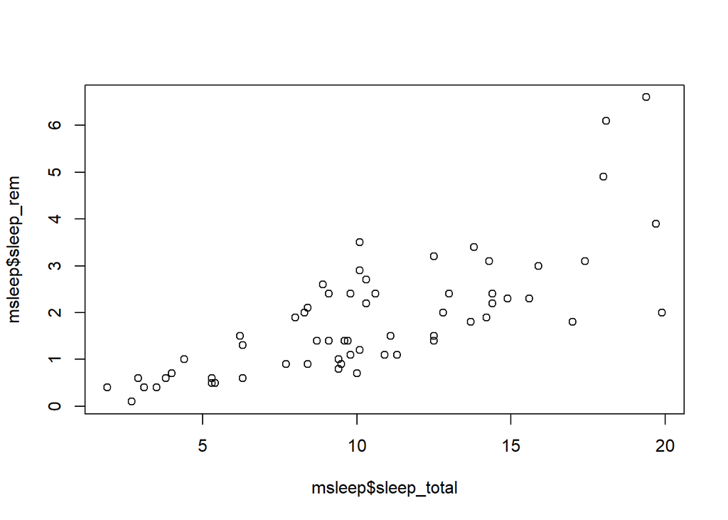

```r
data(msleep)
plot(msleep$sleep_total, msleep$sleep_rem)
```

ggplot:

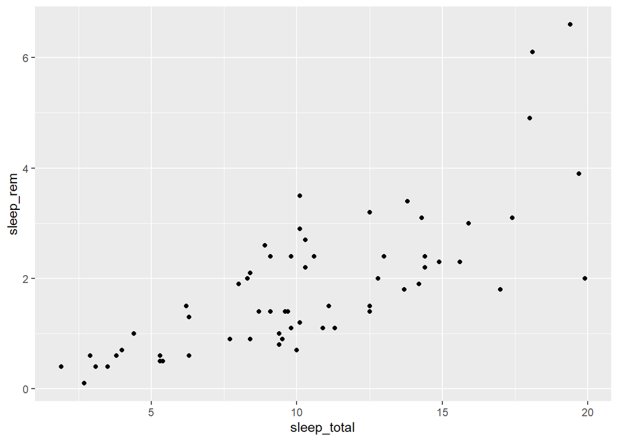

```r
ggplot(msleep, aes(x = sleep_total,
                   y = sleep_rem)) +
  geom_point()
```

We need three components:

- the data set (here, msleep)
- the aesthetics (the x axis, y axis)
- geoms (what do we want to plot, e.g. geom_point for a scatter plot)

So your ggplot function will always have the structure of

ggplot(data, aes) + geom

## Simple style tips

Personally I’m not a fan of the grey background, we can change this by adding a theme, e.g. theme_bw()

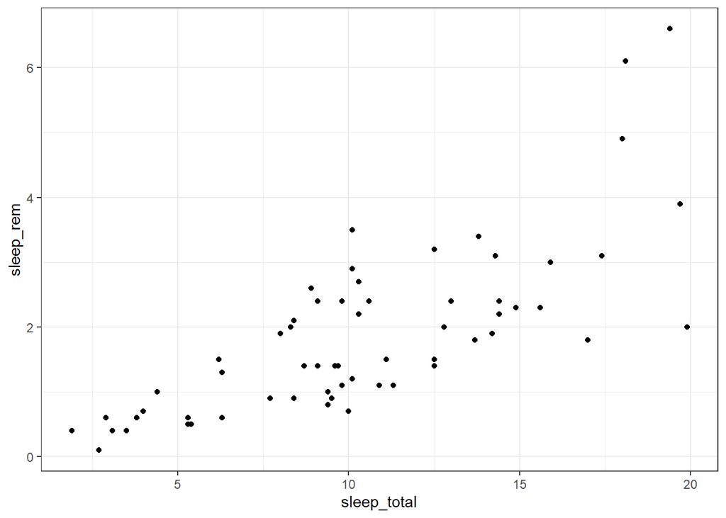

```r
ggplot(msleep, aes(x = sleep_total,
                   y = sleep_rem)) +
  geom_point() +
  theme_bw()
```

We can change the axis labels and title like so:

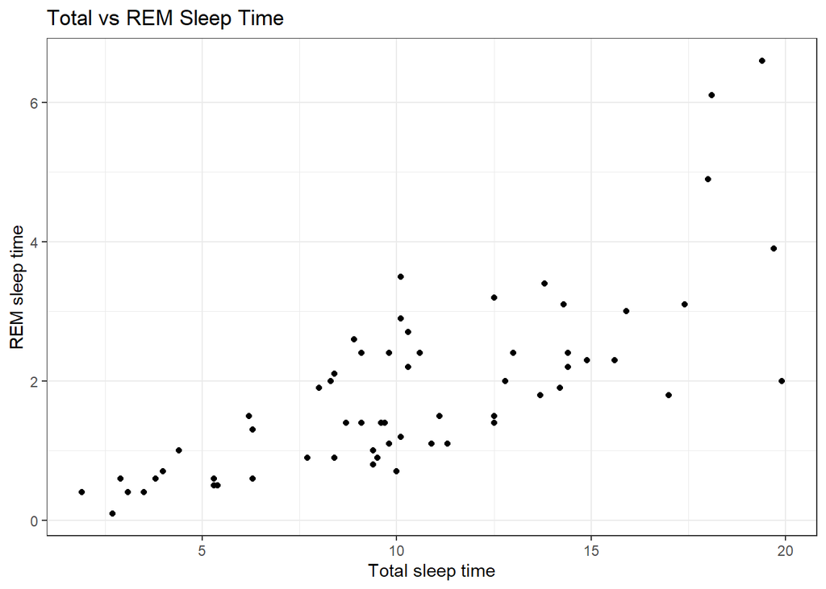

```r
ggplot(msleep, aes(x = sleep_total,
                   y = sleep_rem)) +
  geom_point() +
  theme_bw() +
  labs(x = "Total sleep time",
       y = "REM sleep time",
       title = "Total vs REM Sleep Time")
```

We can plot different colors for different groups by adding a color argument to the aesthetic:

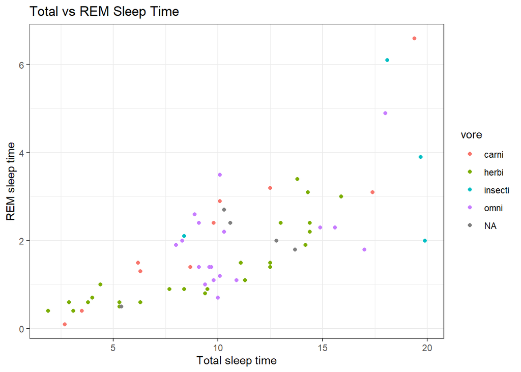

```r
ggplot(msleep, aes(x = sleep_total,
                   y = sleep_rem,
                   color = vore)) +
  geom_point() +
  theme_bw() +
  labs(x = "Total sleep time",
       y = "REM sleep time",
       title = "Total vs REM Sleep Time")
```

Let’s create a plot to see how animals’ brain weight is related to their body weight:

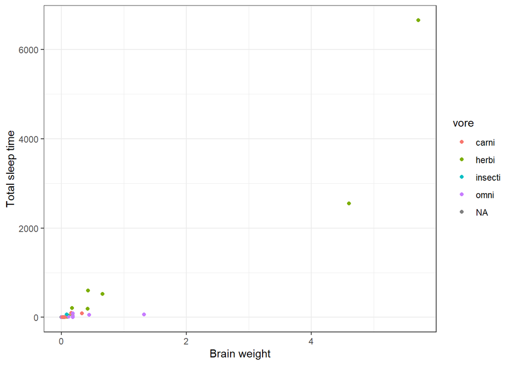

```r
ggplot(msleep, aes(brainwt, bodywt, colour = vore)) +
      geom_point() +
      xlab("Brain weight") +
      ylab("Total sleep time") +
  theme_bw()
```

We have a couple of outliers that are making the overall pattern difficult to interpret. We can address this by changing the x-axis and y-axis limits (although be aware that we are now excluding some data points from the plot):

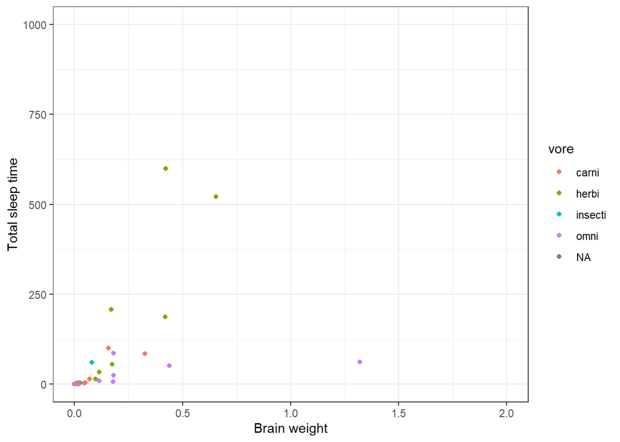

```r
ggplot(msleep, aes(brainwt, bodywt, colour = vore)) +
      geom_point() +
      xlab("Brain weight") +
      ylab("Total sleep time") +
  theme_bw() +
  xlim(0, 2) +
  ylim(0, 1000)
```

We can use facet_wrap to create a separate plot for different groups:

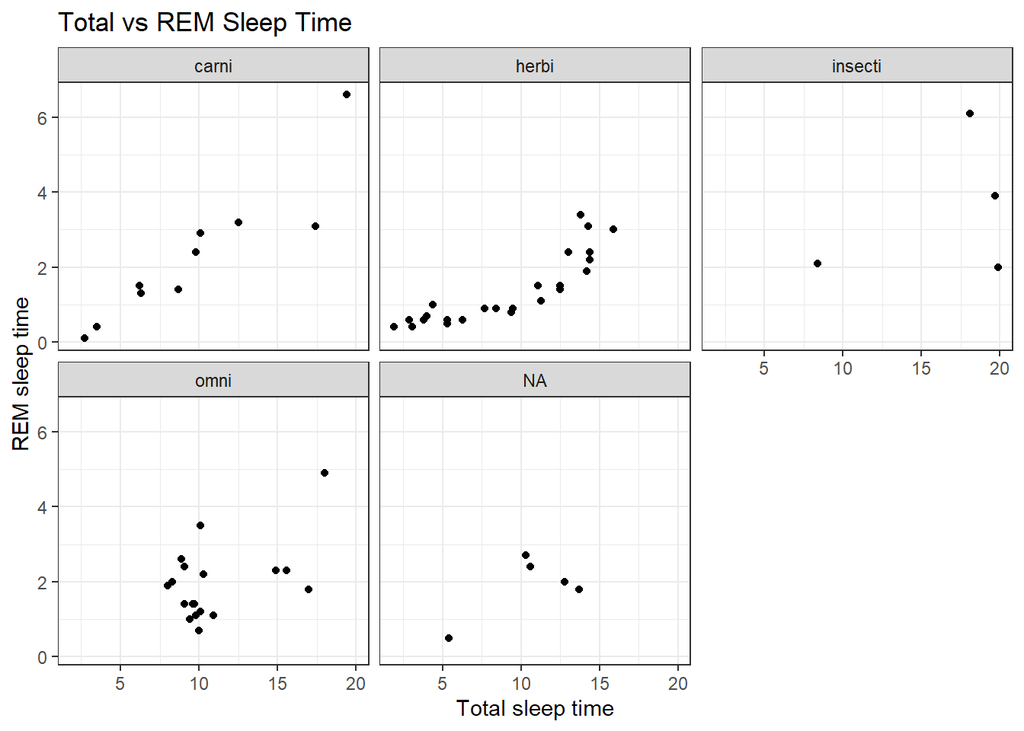

```r
ggplot(msleep, aes(x = sleep_total,
                   y = sleep_rem)) +
  geom_point() +
  theme_bw() +
  labs(x = "Total sleep time",
       y = "REM sleep time",
       title = "Total vs REM Sleep Time") +
  facet_wrap(~vore)
```

## Boxplots

We can do this using base R or ggplot:

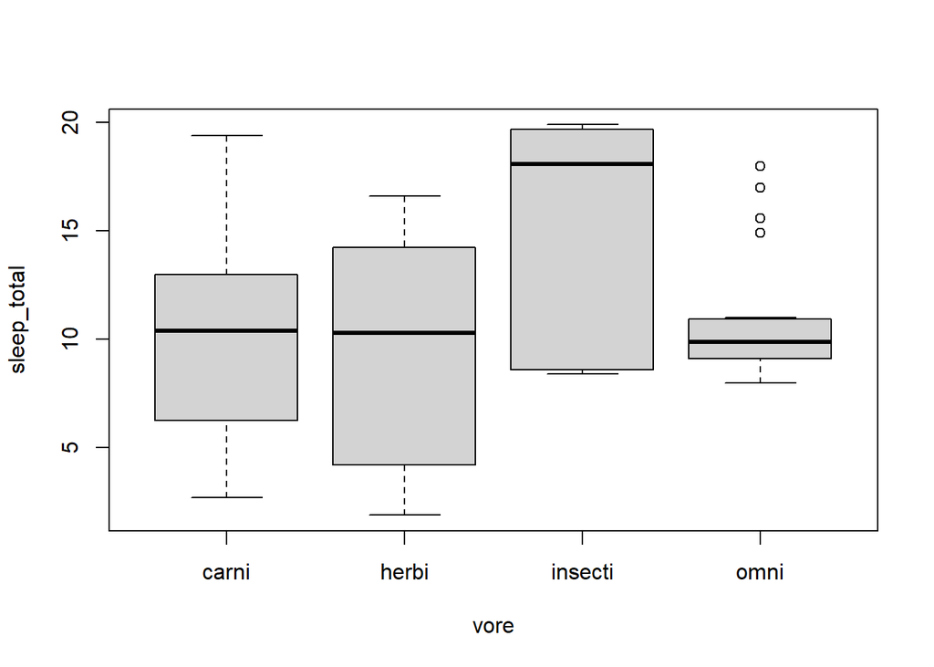

```r
boxplot(sleep_total ~ vore, data = msleep)
```

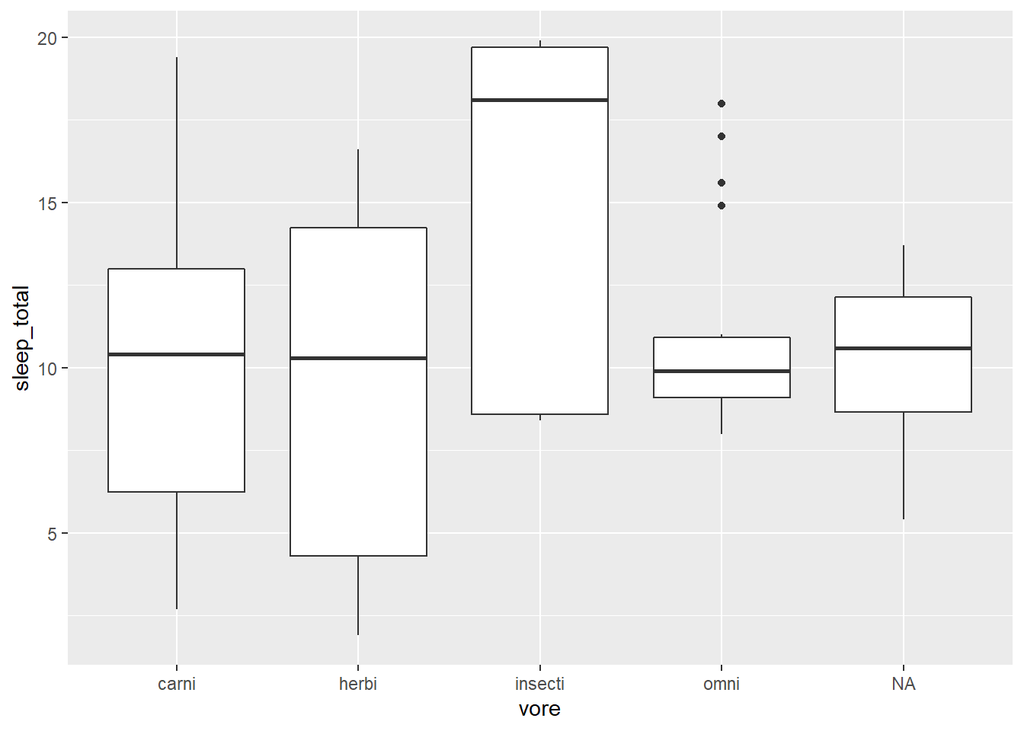

```r
ggplot(msleep,
       aes(vore, sleep_total)) +
      geom_boxplot()
```

## Histograms

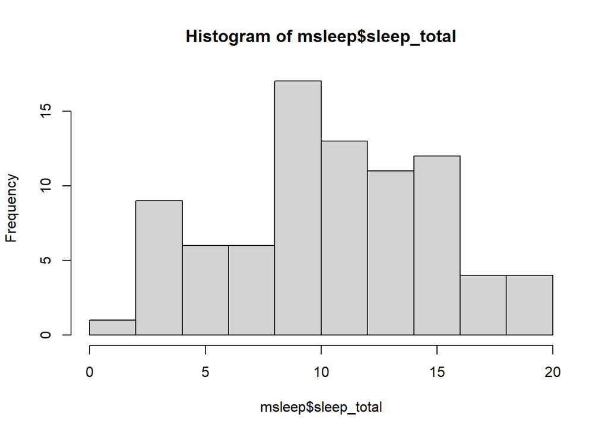

```r
# Base R:
hist(msleep$sleep_total)
```

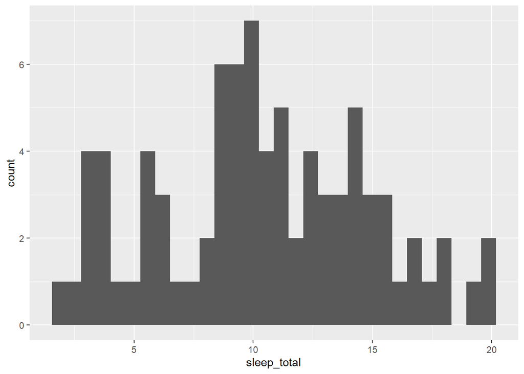

```r
# ggplot2:
ggplot(msleep, aes(sleep_total)) +
      geom_histogram()
```

## Bar charts

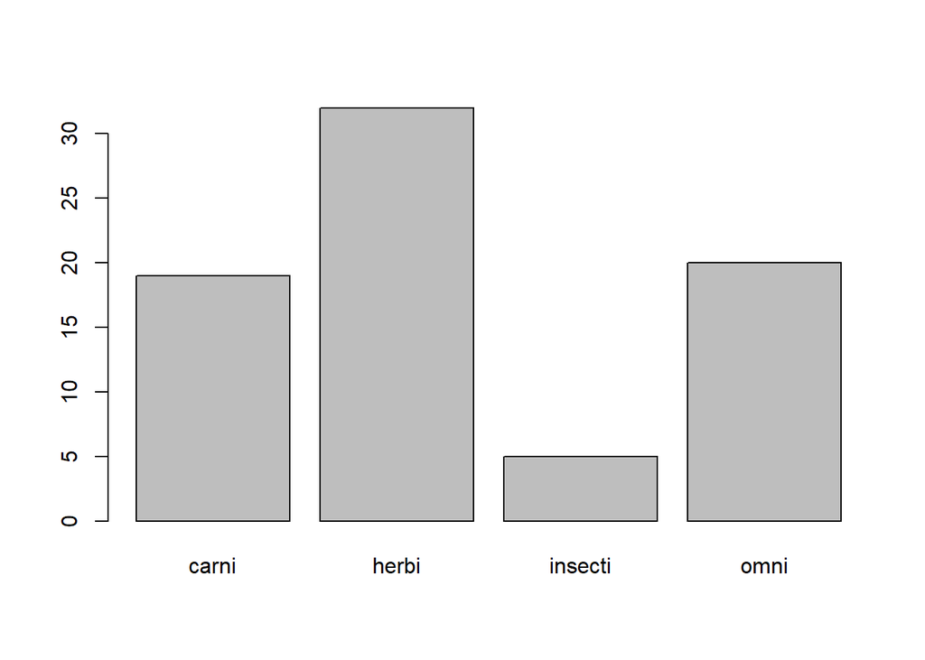

```r
# Base R
barplot(table(msleep$vore))
```

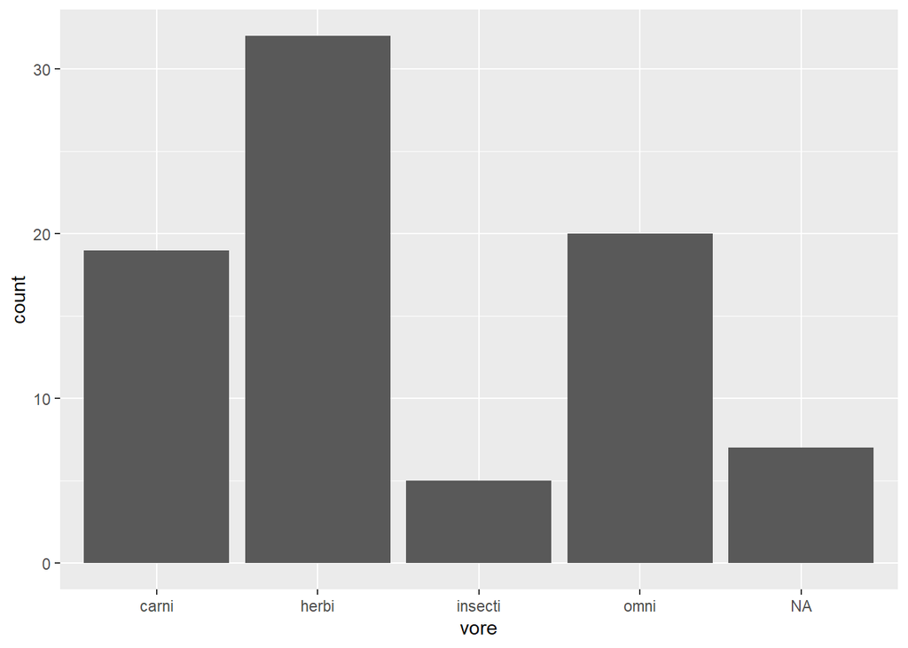

```r
# ggplot2
ggplot(msleep, aes(vore)) +
      geom_bar()
```

## Saving plots

We can assign a plot we make to a variable name, e.g. myPlot:

```r
myPlot <- ggplot(msleep, aes(sleep_total, sleep_rem)) +
      geom_point()
```

We can then see this just by calling the variable name:

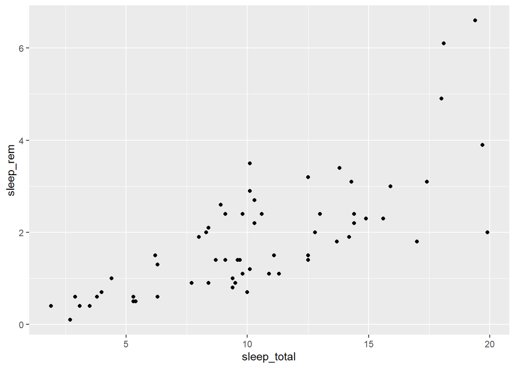

```r
myPlot
```

and add things later:

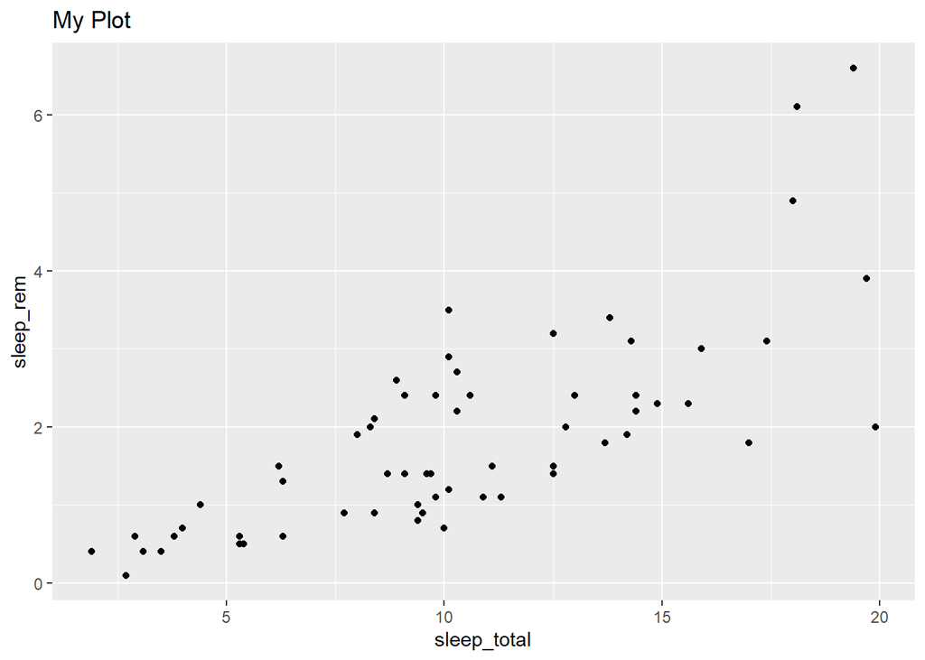

```r
myPlot + labs(title = "My Plot")
```

and finally save it:

```r
ggsave("myplot.pdf", myPlot, width = 5, height = 5)
```

Filtering, merging

Exploring distributions Outliers and missing data Data camp exercises for this part and ggplots!

3.1 Data frames and data types

2.6 Descriptive statistics (numerical and categorical data)

[?2.7 Plotting numerical data]

[3.2 Vectors in data frames]

Using %>% pipes

CHAPTER 5: DEALING WITH MESSY DATA/ DATACAMP: data manipulation with dplyr 5.7 Data manipulation with dplyr [5.8, 5.9, 5.12]

CHAPTER 4: EXPLORATORY DATA ANALYSIS

Reports with R Markdown (maybe next time) Exploring distributions Outliers and missing data

?Scales The full stop in dplyr

```r
write.csv(example_data, "example csv.csv",
          row.names = FALSE)
writexl::write_xlsx(example_data, "example excel.xlsx")
```